# A3 - The Inequality Report

2022-08-10

## An Introduction and summarization

*In this assignment I am choosing certain variables to analyze that highlight inequalities in imprisonment across the south. Specifically, I am observing the state of Texas to see if I can point out some trends in the criminal justice system, over time and observing over a geographical spectrum. The total jail population rate is the average number of people held in jail throughout the year (until December 31st) divided per 1000 people. This is one of the variables I will be using to graph and render some plots along with many other calculated and non-calculated variables.*

*Before we dive into plots, charts, and analyzing trends, here is some calculated background information. The first calculated variable (I mutated and wrangled to get) is called blk_inc_perc. This variable shows the percentage of African Americans who are imprisoned. This variable is per county, and was mutated to a few datasets I created in regards to my area of interest, Texas. I calculated a mean value of blk_inc_perc, mean_value_blk_incperc, which represents the percentage of African Americans in the South (I kept it general and covered the whole South for scope purposes) that are incarcerated; that is **3.32%**. Some more calculations I did to summarize my work are as follows:*

- The maximum value of African American jail rate = **833,333.3** (This may seem weird since this variable is per 1,000 individuals but the values over 1000 account for important discrepancies: illegal emigrants, individuals from different counties wrongfully put in a different counties system, etc..)
- The difference between the total Texas jail population and the African American population, dif_totaljail_to_blkpop in Texas is **50,612,890**.
- There are **121** columns (variables) in the original data set
- There are **153,811** rows (counties by state and year 1970-2018) in the original data set.

## Single Variable Comparison

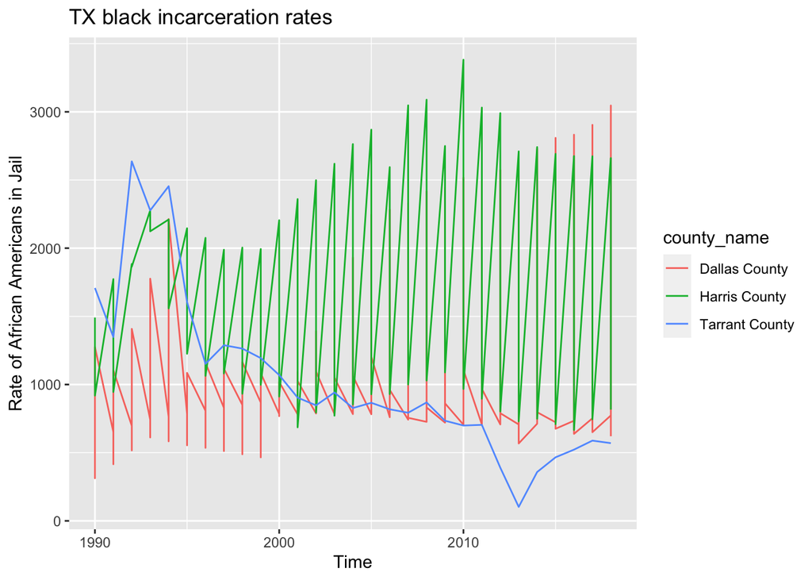